# Estimating Integrated Covariance with OHLC Data

Integrated covariance estimation requires high-frequency asset price data. Unfortunately, tick data, i.e. trade (or quote) data with exact time stamps whenever a trade occurred (or bid/ask quote was available), are expensive. A cost-effective alternative are Open, High, Low, Close (OHLC) data, for example at one-minute resolution. OHLC are trade prices, namely the first, highest, lowest and last trade price within a specific time period. One major advantage of OHLC data is, that they should already be cleaned. In this post I will describe, how to generate a time-series of integrated covariance (IC) matrix estimates from OHLC data.

When estimating integrated Covariance between a *specific set of assets* one has to choose

- *trade prices* or *quote prices*,
- *fixed clock time* or *refresh time* (creating a new price vector once all assets have a new observed price) sampling/alignment,
- the interpolation method (*previous tick interpolation*, *linear interpolation* or some other),
- the sampling window (sample from 9:30 to 16:00; sample from open to close [which on some days is not 9:30 to 16:00]; sample from 15 minuts after open to 15 minute before close; sample all minutes before and after regular trading hours, if enough data is available on all assets one is interested in),
- including overnight returns or not (and how to weight them) and
- what to do with trading halt minutes for some or all of the assets (conditional on the number of trading-silent assets, exclude minute or interpolate price data from beginning to end of halt).

In case of *fixed clock time* sampling/alignment one further has to decide,

- the sampling frequency (…, 1-min, 5-min, …) and
- whether to do subsampling or not.

Finally one has to choose one of numerous estimators of integrated Covariance which works with the choices made above.

I refer to [Park and Linton (2012)](https://doi.org/10.1002/9781118272039.ch13) for an excellent overview of some of the concepts above.

# OHLC Data

We have one-minute OHLC data (*trade prices*) from 1998-01-02 to 2021-03-13. Consequently, we are already facing an *equally spaced (i.e. regular) grid*. i.e. *fixed clock time* sampling/alignment (e.g. 09:00, 09:01, 09:02, …). Which of the four prices (OHLC) should we choose for IC estimation? Only the Close price makes sense. To see this, consider a specific minute (e.g. from 09:00:00 until 09:00:59). Recording at the end of each minute, the price of the latest trade (Close price) in that minute corresponds to the sensible (since it is in accordance with the common semi-martingale assumption on price processes) *previous tick interpolation*. Recording the High or Low price for either the end or the beginning of that minute obviously does not make sense, since, well we have another price which occured closer to that time stamp. The only left alternative might be to record the open price for the beginning of that minute. However, this would constitute a weird “backwards-in-time” interpolation method, which conflicts with the semi-martingale assumption on price processes.

So three of the choices above have already been done for us (*trade prices*, *fixed clock time* sampling on an *equally spaced grid* and *previous tick interpolation*).

Our data also contains before and after hours trading. Obviously trade prices during official trading hours are generated under very different circumstances from non-trading hours (for example liquidity differs dramatically). It is thus common practice to eliminate observations before and after a market is closed. Our data are consolidated from different exchanges, of which the biggest are the NYSE, NASDAQ and AMEX (AMEX was bought by NYSE in 2008, and handled only 10% of trades at its height). Unfortunaltely different exchanges sometimes have different open or close times and those are not recorded or in the public domain (especially for NASDAQ prior to 2010).

The sampling frequency is one minute. Only when the stock was actually traded in the respective time interval (1-min in our case) an OHLC observation is recorded. Dates on which all stock exchanges were closed unexpectedly (e.g. the days after 9/11) are obviously already excluded.

Also trading halts are not recorded. My own attempts to identify and exclude minutes within usual trading hours where some stock exchanges were closed fail due to unavailable data (See my incomplete try in the file *data_minute_cleaning.Rmd*).

# 2 Estimation of Integrated Covariance

I follow [Noureldin, Shephard and Sheppard (2012)](https://doi.org/10.1002/jae.1260) in choosing the starting date for the sample to be after decimal pricing had been fully implemented in the NYSE, which took place on 2001-01-29. As seen above, we have to use *trade prices*, *fixed clock time* sampling/alignment, *previous tick interpolation*. I choose to decrease the sampling frequency to 5-min with 1-min subsampling, following [Opschoor, Janus, Lucas and Van Dijk (2018)](https://doi.org/10.1080/07350015.2016.1245622) and [Noureldin, Shephard and Sheppard (2012)](https://doi.org/10.1002/jae.1260) and since [Liu, Patton and Sheppard (2015)](https://doi.org/10.1016/j.jeconom.2015.02.008) show that 5-min realized variance based on subsampling is seldomly outperformed. I will sample from 9:30 to 16:00 on every day (which always covers trading hours) due to the difficulty of identifying closed minutes. I want to use the standard *realized covariance* estimator.

## 2.1 Minute Cleaning

1. late opens,
2. early closes,
3. long trading silence in at least one asset and
4. specific minutes where many assets did not trade.

### 2.1.1 Late Opens

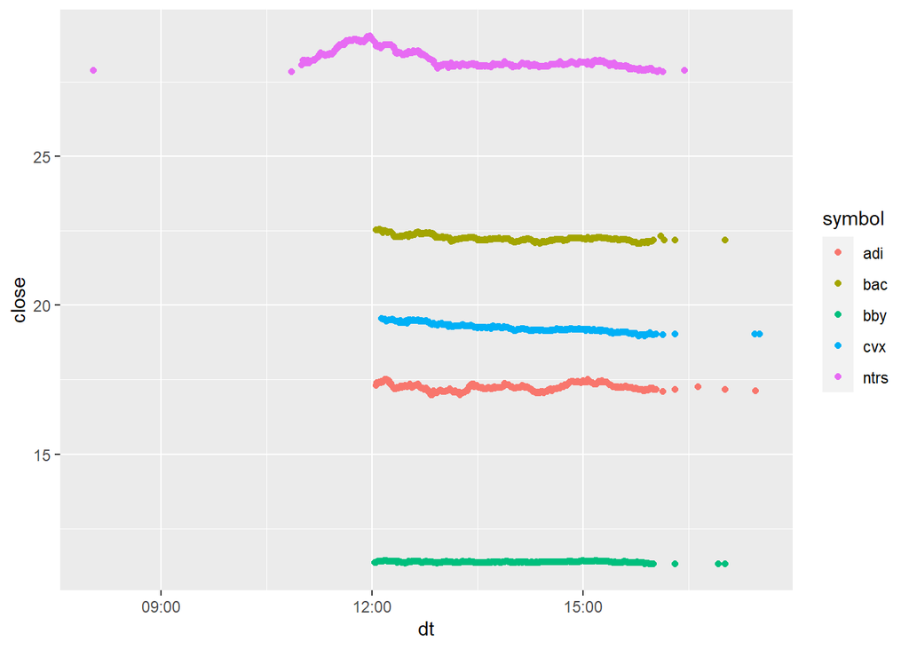

```r
ii <- "2021-02_SP500/03_processed_data/intraday_data/20020911.rds"
symbols <- c("adi", "cvx", "ntrs", "bac", "bby")

read_rds(ii) %>%
  select(dt,symbol,close) %>%
  filter(symbol %in% symbols) %>%
  ggplot(aes(dt,close,col=symbol)) + geom_point()
```

Truncate the sample at the beginning acc. to the following rule:

1. Eliminate all observations prior to when all symbols have been observed at least once.
2. Eliminate subsequent minutes until for the first time 90% of symbols-mins  
   are observed in the following 1 and 5 min interval [likely the opening minute].

This eliminates mins prior to late opens automatically.

### 2.1.2 Early Closes

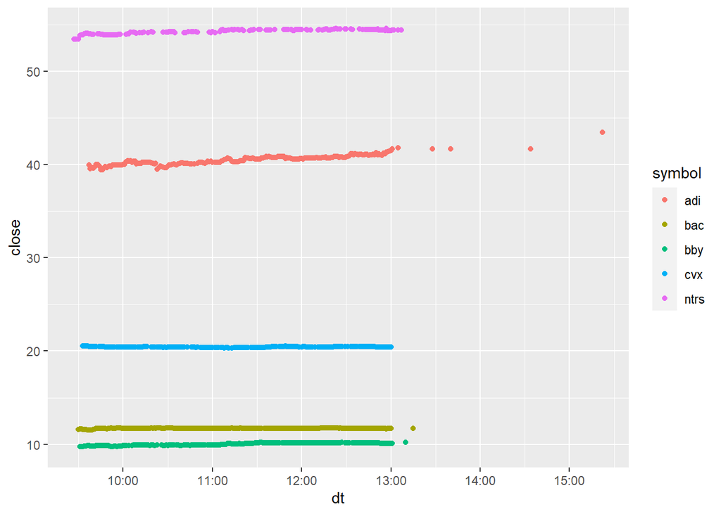

```r
ii <- "2021-02_SP500/03_processed_data/intraday_data/20001124.rds"

read_rds(ii) %>%
  select(dt,symbol,close) %>%
  filter(symbol %in% symbols) %>%
  ggplot(aes(dt,close,col=symbol)) + geom_point()
```

Truncate the sample at the end acc. to the same rule as in 1., but reverse. I.e. flip upside down the arrays and repeat 1.)

This eliminates mins after early closes automatically.

### 2.1.3 Long trading silence in at least one asset

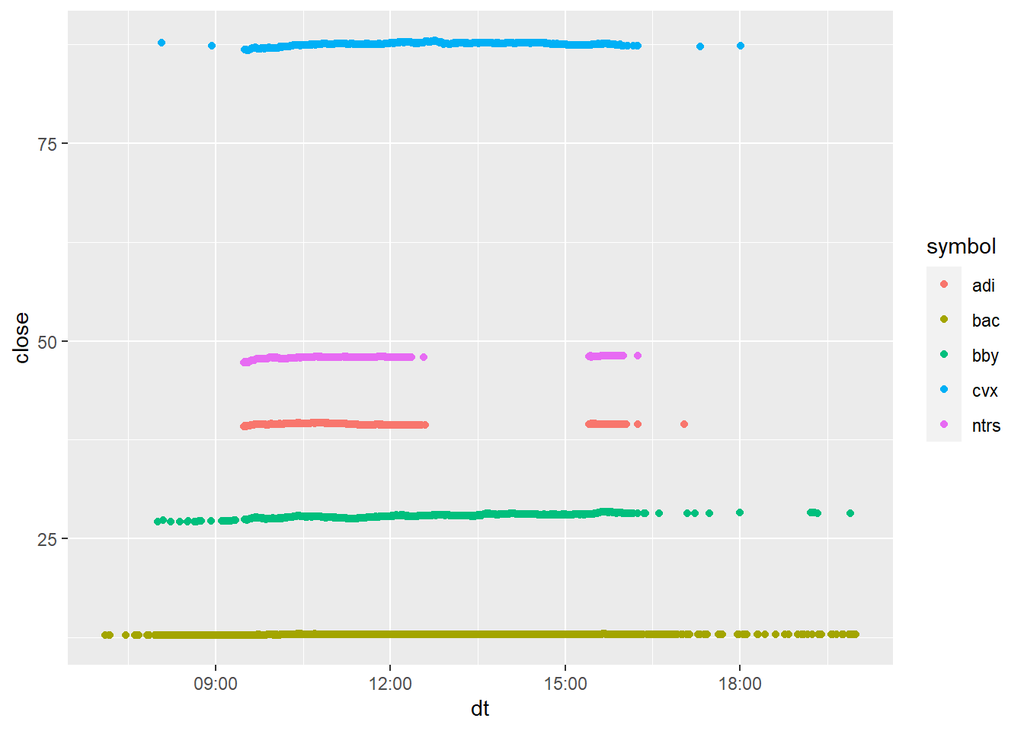

```r
ii <- "2021-02_SP500/03_processed_data/intraday_data/20130822.rds"

read_rds(ii) %>%
  select(dt,symbol,close) %>%
  filter(symbol %in% symbols) %>%
  ggplot(aes(dt,close,col=symbol)) + geom_point()
```

Write NAs in all series if in at least one series there are 10 consecutive NAs.

### 2.1.4 Minutes with a lot of missing values

Write NAs in all series if in the respective min more than 90% of symbols have NAs.

## 2.2 Procedure Description

1. Put 1-min OHLC data on max-grid-per-day, with NA entries if symbol wasn’t traded in minute
2. Do previous tick interpolation on all minutes.
3. Clean mins as described above.
4. Calculate Subsampled 5-min returns on 930-1600 grid
5. Throw away mins with NA returns and calculate RCs.